# Life-Expectancy-Analysis

```python
%matplotlib inline
import pandas as pd

# Dataset
path = "D:/Datasets1/Life Expectancy Data.csv"
df = pd.read_csv(path)
df.head()
```

|  | Country | Year | Status | Life expectancy | Adult Mortality | infant deaths | Alcohol | percentage expenditure | Hepatitis B | Measles | ... | Polio | Total expenditure | Diphtheria | HIV/AIDS | GDP | Population | thinness 1-19 years | thinness 5-9 years | Income composition of resources | Schooling |
| --- | --- | --- | --- | --- | --- | --- | --- | --- | --- | --- | --- | --- | --- | --- | --- | --- | --- | --- | --- | --- | --- |
| 0 | Afghanistan | 2015 | Developing | 65.0 | 263.0 | 62 | 0.01 | 71.279624 | 65.0 | 1154 | ... | 6.0 | 8.16 | 65.0 | 0.1 | 584.259210 | 33736494.0 | 17.2 | 17.3 | 0.479 | 10.1 |
| 1 | Afghanistan | 2014 | Developing | 59.9 | 271.0 | 64 | 0.01 | 73.523582 | 62.0 | 492 | ... | 58.0 | 8.18 | 62.0 | 0.1 | 612.696514 | 327582.0 | 17.5 | 17.5 | 0.476 | 10.0 |
| 2 | Afghanistan | 2013 | Developing | 59.9 | 268.0 | 66 | 0.01 | 73.219243 | 64.0 | 430 | ... | 62.0 | 8.13 | 64.0 | 0.1 | 631.744976 | 31731688.0 | 17.7 | 17.7 | 0.470 | 9.9 |
| 3 | Afghanistan | 2012 | Developing | 59.5 | 272.0 | 69 | 0.01 | 78.184215 | 67.0 | 2787 | ... | 67.0 | 8.52 | 67.0 | 0.1 | 669.959000 | 3696958.0 | 17.9 | 18.0 | 0.463 | 9.8 |
| 4 | Afghanistan | 2011 | Developing | 59.2 | 275.0 | 71 | 0.01 | 7.097109 | 68.0 | 3013 | ... | 68.0 | 7.87 | 68.0 | 0.1 | 63.537231 | 2978599.0 | 18.2 | 18.2 | 0.454 | 9.5 |

5 rows × 22 columns

```python
# Basic info
print("Dataset info:\n",df.info())
```

```
<class 'pandas.core.frame.DataFrame'>
RangeIndex: 2938 entries, 0 to 2937
Data columns (total 22 columns):
 #   Column                           Non-Null Count  Dtype
---  ------                           --------------  -----
 0   Country                          2938 non-null   object
 1   Year                             2938 non-null   int64
 2   Status                           2938 non-null   object
 3   Life expectancy                  2928 non-null   float64
 4   Adult Mortality                  2928 non-null   float64
 5   infant deaths                    2938 non-null   int64
 6   Alcohol                          2744 non-null   float64
 7   percentage expenditure           2938 non-null   float64
 8   Hepatitis B                      2385 non-null   float64
 9   Measles                          2938 non-null   int64
```

[output cut: 16 more lines]

### Data Cleaning

```python
# Removing duplicate rows
df.drop_duplicates(inplace=True)

# Removing double/multiple spaces in column names and make them consistent
df.columns = df.columns.str.strip().str.lower().str.replace(r'\s+', '_', regex=True)

# Standardizing column names
df.columns = [col.strip().lower().replace(" ", "_") for col in df.columns]

# Removing extra spaces inside string-type values
object_cols = df.select_dtypes(include='object').columns
for col in object_cols:
    df[col] = df[col].str.strip().str.replace(r'\s+', ' ', regex=True)

# Check for missing values
print("\nMissing values:")
print(df.isnull().sum())
```

```
Missing values:
country                              0
year                                 0
status                               0
life_expectancy                     10
adult_mortality                     10
infant_deaths                        0
alcohol                            194
percentage_expenditure               0
hepatitis_b                        553
measles                              0
bmi                                 34
under-five_deaths                    0
polio                               19
total_expenditure                  226
diphtheria                          19
hiv/aids                             0
gdp                                448
population                         652
thinness_1-19_years                 34
thinness_5-9_years                  34
income_composition_of_resources    167
schooling                          163
dtype: int64
```

```python
from sklearn.experimental import enable_iterative_imputer
from sklearn.impute import IterativeImputer

# Dropping rows with missing life_expectancy (target variable)
df = df.dropna(subset=["life_expectancy"])

# Separating numeric and non-numeric data
numeric_df = df.select_dtypes(include='number')
non_numeric_df = df.select_dtypes(exclude='number').reset_index(drop=True)

# Applying IterativeImputer (Replacing missing values using relationships across other columns)
imp = IterativeImputer(random_state=0)
numeric_imputed = pd.DataFrame(imp.fit_transform(numeric_df), columns=numeric_df.columns)

# Merge back
df_imputed = pd.concat([non_numeric_df, numeric_imputed], axis=1)

# Checking for missing values in df_imputed
df_imputed.isnull().sum().sort_values(ascending=False)
```

```
country                            0
status                             0
income_composition_of_resources    0
thinness_5-9_years                 0
thinness_1-19_years                0
population                         0
gdp                                0
hiv/aids                           0
diphtheria                         0
total_expenditure                  0
polio                              0
under-five_deaths                  0
bmi                                0
measles                            0
hepatitis_b                        0
percentage_expenditure             0
alcohol                            0
infant_deaths                      0
adult_mortality                    0
life_expectancy                    0
year                               0
schooling                          0
dtype: int64
```

### Exploratory Data Analysis

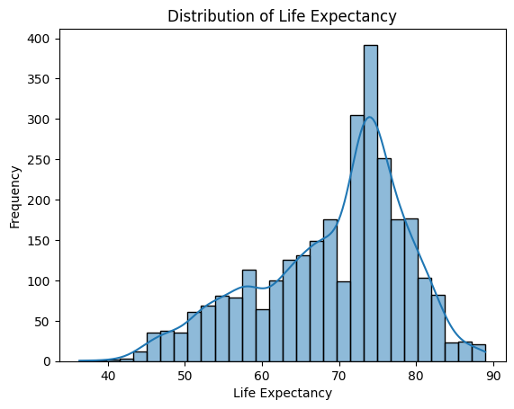

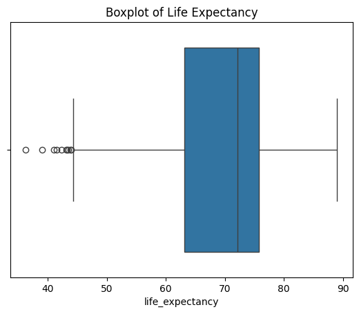

```python
import seaborn as sns
import matplotlib.pyplot as plt

# Histogram + KDE
sns.histplot(df_imputed['life_expectancy'], kde=True, bins=30)
plt.title("Distribution of Life Expectancy")
plt.xlabel("Life Expectancy")
plt.ylabel("Frequency")
plt.show()

# Boxplot
sns.boxplot(x=df_imputed['life_expectancy'])
plt.title("Boxplot of Life Expectancy")
plt.show()
```

**1. Histogram + KDE Plot (Distribution of Life Expectancy)**

**Interpretation:**

- Life expectancy is not perfectly normally distributed; it has a moderate skew.
- A majority of observations fall within a healthy range, but there's a significant portion of lower values (likely countries with poor healthcare or high mortality).

**2. Boxplot (Life Expectancy)**

**Interpretation:**

- Most countries have life expectancy clustered around the median.
- Outliers on the low end indicate some nations are significantly behind, possibly due to war, famine, epidemics, etc.

**Summary:**

- Life expectancy data is slightly skewed, but mostly unimodal and concentrated in a healthy range.
- A few outliers reflect poor conditions in some countries.

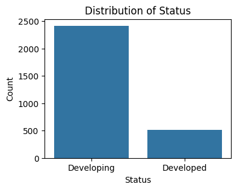

```python
# Visualizing distribution of status
plt.figure(figsize=(4, 3))
sns.countplot(data=df_imputed, x='status')
plt.title('Distribution of Status')
plt.xlabel('Status')
plt.ylabel('Count')
plt.show()
```

**Interpretation** The countplot of "status" shows that the dataset is imbalanced, with significantly more entries for developing countries (around 2400) compared to developed countries (around 500). This suggests that most data points represent developing nations, which may influence the model's learning and predictions if "status" is used as a feature.

```python
import math

# Select numeric features excluding the target
numeric_cols = df_imputed.select_dtypes(include='number').columns.drop('life_expectancy')
```

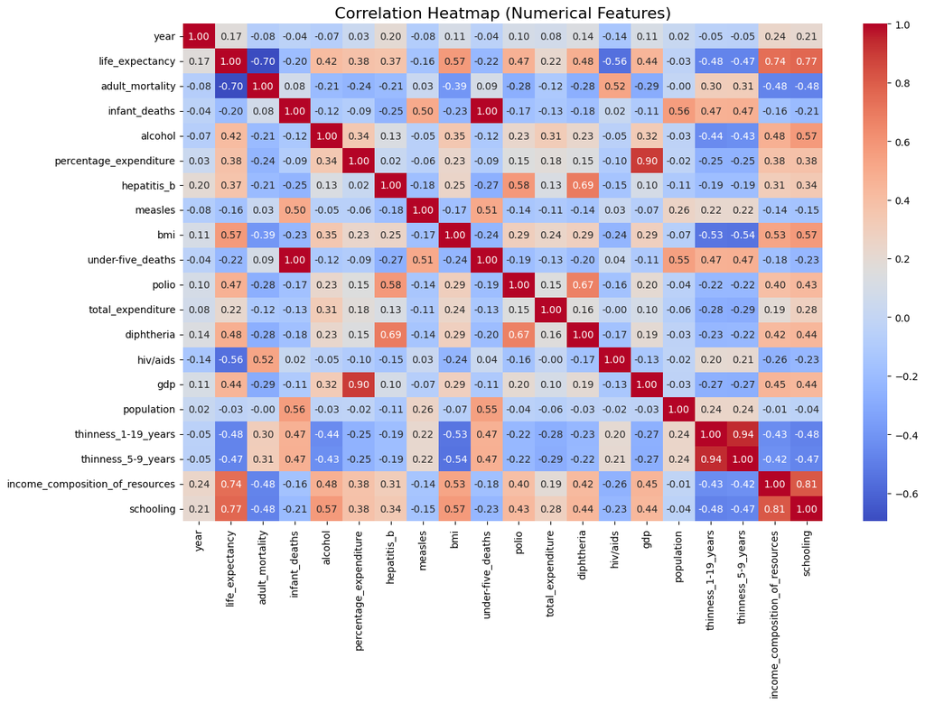

```python
# Compute correlation matrix (numeric only)
corr_matrix = df_imputed.corr(numeric_only=True)

# Correlation heatmap
plt.figure(figsize=(14, 10))
sns.heatmap(df_imputed.corr(numeric_only=True), cmap='coolwarm', annot=True, fmt=".2f",)
plt.title("Correlation Heatmap (Numerical Features)", fontsize=16)
plt.tight_layout()
plt.show()
```

```python
# Using VIF to Quantify Redundancy

from statsmodels.stats.outliers_influence import variance_inflation_factor
from statsmodels.tools.tools import add_constant

X = df_imputed.drop(columns=['life_expectancy'])  # drop target
X_const = add_constant(X.select_dtypes(include='number'))  # numeric only

vif_df = pd.DataFrame()
vif_df['feature'] = X_const.columns
vif_df['VIF'] = [variance_inflation_factor(X_const.values, i) for i in range(X_const.shape[1])]
vif_df
```

|  | feature | VIF |
| --- | --- | --- |
| 0 | const | 226863.698533 |
| 1 | year | 1.205051 |
| 2 | adult_mortality | 1.806624 |
| 3 | infant_deaths | 178.800023 |
| 4 | alcohol | 1.882235 |
| 5 | percentage_expenditure | 5.911082 |
| 6 | hepatitis_b | 2.181715 |
| 7 | measles | 1.379458 |
| 8 | bmi | 1.812122 |
| 9 | under-five_deaths | 178.001233 |
| 10 | polio | 2.018449 |
| 11 | total_expenditure | 1.254468 |
| 12 | diphtheria | 2.597851 |
| 13 | hiv/aids | 1.444179 |
| 14 | gdp | 6.205959 |
| 15 | population | 1.506415 |
| 16 | thinness_1-19_years | 8.765241 |
| 17 | thinness_5-9_years | 8.854317 |
| 18 | income_composition_of_resources | 3.297053 |
| 19 | schooling | 4.007221 |

##### **Interpretation of Correlation Heatmap and VIF Analysis**

**Correlation Heatmap Analysis**

- Strong Positive Correlations:
  - life_expectancy with income_composition_of_resources (0.74) and schooling (0.77)
  - infant_deaths with under-five_deaths (1.00): this is a perfect correlation indicating these are essentially measuring the same thing
  - thinness_1-19_years with thinness_5-9_years (0.94): very highly correlated
  - income_composition_of_resources with schooling (0.81)
- Strong Negative Correlations:
  - life_expectancy with adult_mortality (-0.70): as expected, higher mortality lowers life expectancy
  - thinness_1-19_years with income_composition_of_resources (-0.43) and schooling (-0.48)
- Interesting Relationships:
  - year has very low correlations with other variables (all < 0.24)
  - gdp is highly correlated with percentage_expenditure (0.90)
  - polio and diphtheria are highly correlated (0.67)

**VIF Analysis**

The Variance Inflation Factor (VIF) confirms multicollinearity issues:

- Severe Multicollinearity (VIF > 10):
  - Infant Deaths (178.80) & Under-Five Deaths (178.00): Must remove one to avoid model instability.
- High Multicollinearity (5 ≤ VIF < 10):
  - Thinness 1-19 Years (8.77) & Thinness 5-9 Years (8.85): Nearly identical —> keep only one.
  - GDP (6.21) & Percentage Expenditure (5.91): Economic indicators with strong overlap.
- Moderate Multicollinearity (VIF < 5):
  - Schooling (4.01) & Income Composition (3.30): Some correlation but may be acceptable if theoretically justified.

**Decisions for Model Improvement**

```python
df_imputed = df_imputed.drop(columns=['infant_deaths', 'thinness_5-9_years', 'year'])

# Updating numeric features
numeric_cols = df_imputed.select_dtypes(include='number').columns.drop('life_expectancy')
```

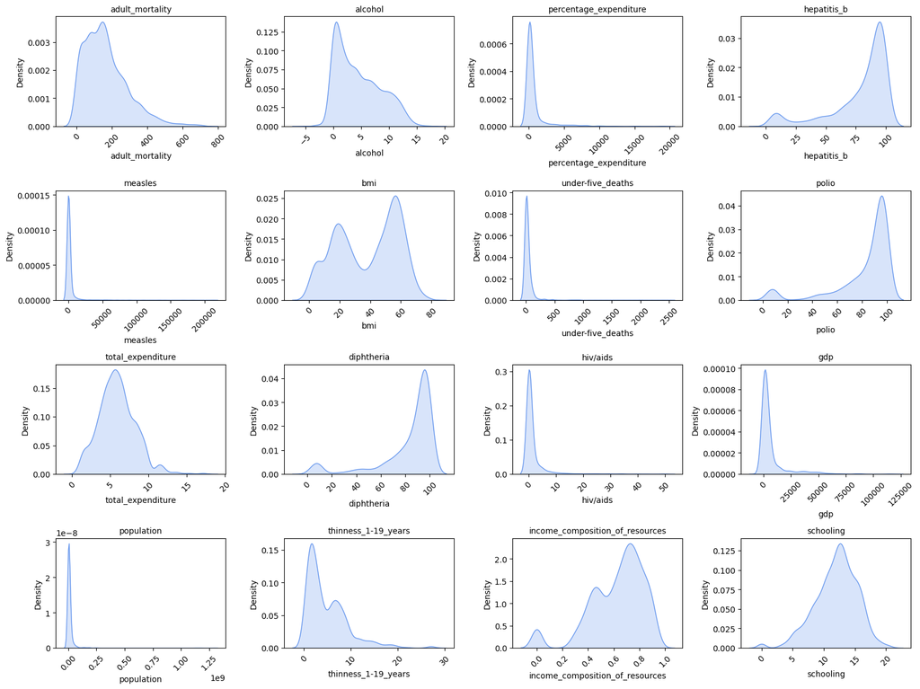

```python
# Visualizing the numerical variables distributions

# Layout config
plots_per_row = 4
num_plots = len(numeric_cols)
num_rows = math.ceil(num_plots / plots_per_row)

# Set up subplots
fig, axes = plt.subplots(num_rows, plots_per_row, figsize=(plots_per_row * 4, num_rows * 3))
axes = axes.flatten()

# Plot KDEs
for i, col in enumerate(numeric_cols):
    sns.kdeplot(data=df_imputed, x=col, ax=axes[i], fill=True, color='cornflowerblue')
    axes[i].set_title(col, fontsize=10)
    axes[i].tick_params(axis='x', labelrotation=45)

# Hide unused subplots
for j in range(i + 1, len(axes)):
    axes[j].axis('off')

plt.tight_layout()
plt.show()
```

**Interpretation:** What the KDE Plots Show

- Skewed Distributions (Highly Asymmetric): Variables with strong right or left skew: **percentage_expenditure, gdp, measles, population, hiv/aids, under-five_deaths**, these have long tails, many values near 0, and few very large values.

→ These need scaling or transformation.

- Bimodal or Multimodal Distributions: **bmi, income_composition_of_resources**, these show multiple peaks → could indicate different subpopulations (e.g., developing vs developed countries).

→ we might want to analyze these separately by status.

**Problem:** Different Scales Across Variables

**→** We might apply scaling later

```python
# Dropping country variable (not essential and can't be converted to numerical)
df_model = df_imputed.drop(columns=['country'])

# Encoding status feature to 0/1
df_model['status'] = df_model['status'].map({'Developing': 0, 'Developed': 1})
```

### Feature Selection

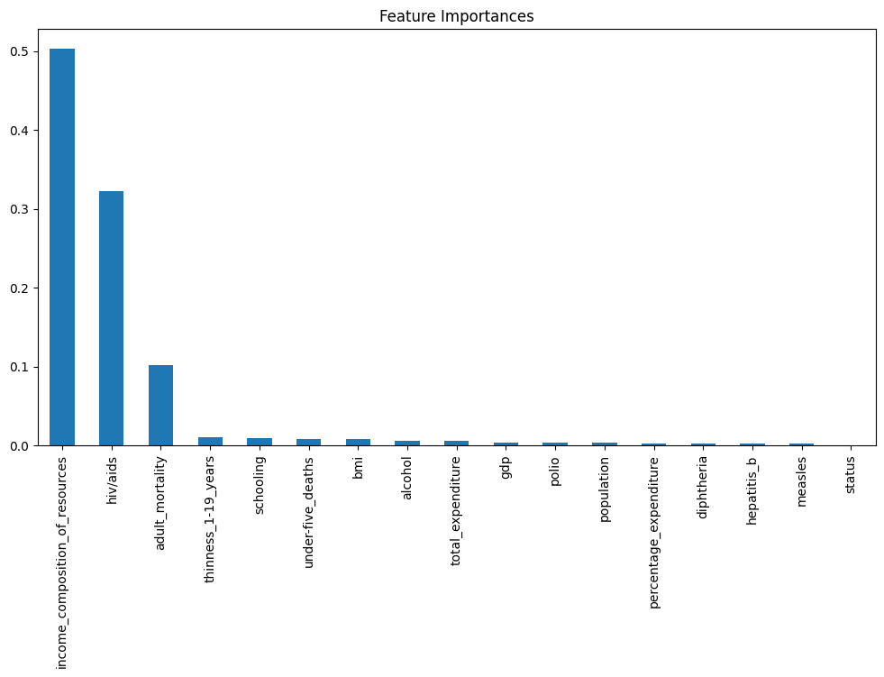

```python
# Feature Importance via a Simple Model

X = df_model.drop(columns='life_expectancy')
y = df_model['life_expectancy']

from sklearn.ensemble import RandomForestRegressor

model = RandomForestRegressor(random_state=42)
model.fit(X, y)

importances = pd.Series(model.feature_importances_, index=X.columns).sort_values(ascending=False)
importances.plot(kind='bar', figsize=(12, 6), title="Feature Importances")
```

```python
from sklearn.preprocessing import StandardScaler

# scaler and fit-transform
scaler = StandardScaler()
df_imputed[numeric_cols] = scaler.fit_transform(df_imputed[numeric_cols])
```

```python
# Recursive Feature Elimination (RFE)

from sklearn.feature_selection import RFE
from sklearn.linear_model import LinearRegression

lr = LinearRegression()
rfe = RFE(lr, n_features_to_select=10)
rfe.fit(X, y)

selected_features = X.columns[rfe.support_]
print("Selected features:", list(selected_features))
```

```
Selected features: ['status', 'alcohol', 'bmi', 'polio', 'total_expenditure', 'diphtheria', 'hiv/aids', 'thinness_1-19_years', 'income_composition_of_resources', 'schooling']
```

- **RandomForestRegressor (Tree-based Model):**
  - Feature importances:
    - income_composition_of_resources: ~0.50
    - hiv/aids: ~0.33
    - adult_mortality: ~0.10
    - All others: < 0.03
  - This tells us that these top 3 features are doing almost all the work in explaining life_expectancy using non-linear splits. The rest have minimal or no contribution in this model.
- **LinearRegression + RFE:**
  - Selected 10 features: these are features that are linearly predictive, not necessarily the most powerful for complex models.
  - LinearRegression is sensitive to multicollinearity and scale, so features like schooling and total_expenditure may seem more valuable here than they really are in a non-linear context.

```python
# features to keep
selected_features = ['income_composition_of_resources', 'hiv/aids', 'adult_mortality', 'thinness_1-19_years', 'schooling', 'bmi']
```

### Modeling

```python
# Train-Test-Split

from sklearn.model_selection import train_test_split

X = df_imputed[selected_features]
y = df_imputed['life_expectancy']

# Split
X_train, X_test, y_train, y_test = train_test_split(X, y, test_size=0.2, random_state=42)
```

```python
# Model training and evaluation

from sklearn.linear_model import LinearRegression
from sklearn.metrics import mean_squared_error, r2_score
from sklearn.ensemble import RandomForestRegressor
from sklearn.metrics import r2_score, mean_squared_error
from sklearn.linear_model import LinearRegression, Ridge
from sklearn.ensemble import RandomForestRegressor
import xgboost as xgb
```

```python
# Linear Regression

lr = LinearRegression()
lr.fit(X_train, y_train)

y_pred_lr = lr.predict(X_test)

print("Linear Regression:")
print("R² Score:", r2_score(y_test, y_pred_lr))
print("RMSE:", mean_squared_error(y_test, y_pred_lr))
```

```
Linear Regression:
R² Score: 0.8155196904442911
RMSE: 15.957436516872342
```

```python
# Random Forest Regressor

rf = RandomForestRegressor(random_state=42)
rf.fit(X_train, y_train)

y_pred_rf = rf.predict(X_test)

print("Random Forest:")
print("R² Score:", r2_score(y_test, y_pred_rf))
print("RMSE:", mean_squared_error(y_test, y_pred_rf))
```

```
Random Forest:
R² Score: 0.9676517392408704
RMSE: 2.798105221843001
```

```python
# Ridge Regression

ridge = Ridge(alpha=1.0)
ridge.fit(X_train, y_train)
y_pred_ridge = ridge.predict(X_test)

print("Ridge Regression:")
print("R² Score:", r2_score(y_test, y_pred_ridge))
print("RMSE:", mean_squared_error(y_test, y_pred_ridge))
```

```
Ridge Regression:
R² Score: 0.8155245021486581
RMSE: 15.957020307320443
```

```python
# XGBoost Regressor

xgbr = xgb.XGBRegressor(random_state=42)
xgbr.fit(X_train, y_train)
y_pred_xgb = xgbr.predict(X_test)

print("XGBoost:")
print("R² Score:", r2_score(y_test, y_pred_xgb))
print("RMSE:", mean_squared_error(y_test, y_pred_xgb))
```

```
XGBoost:
R² Score: 0.9646399299421403
RMSE: 3.0586249260930525
```

```python
# Creating empty lists
model_names = []
r2_scores = []
rmse_scores = []

# Appending model results
model_names.append("Linear Regression")
r2_scores.append(r2_score(y_test, y_pred_lr))
rmse_scores.append(mean_squared_error(y_test, y_pred_lr))  # correct usage

model_names.append("Random Forest")
r2_scores.append(r2_score(y_test, y_pred_rf))
rmse_scores.append(mean_squared_error(y_test, y_pred_rf))

model_names.append("Ridge")
r2_scores.append(r2_score(y_test, y_pred_ridge))
rmse_scores.append(mean_squared_error(y_test, y_pred_ridge))

model_names.append("XGBoost")
r2_scores.append(r2_score(y_test, y_pred_xgb))
rmse_scores.append(mean_squared_error(y_test, y_pred_xgb))

# Creating results DataFrame
results_df = pd.DataFrame({
    "Model": model_names,
    "R2": r2_scores,
    "RMSE": rmse_scores
})

# Sort and display
results_df.sort_values(by="R2", ascending=False)
```

|  | Model | R2 | RMSE |
| --- | --- | --- | --- |
| 1 | Random Forest | 0.967652 | 2.798105 |
| 3 | XGBoost | 0.964640 | 3.058625 |
| 2 | Ridge | 0.815525 | 15.957020 |
| 0 | Linear Regression | 0.815520 | 15.957437 |

**Interpretation**

- Random Forest is the clear winner, it captures non-linear relationships exceptionally well.
- XGBoost is very close and may generalize slightly better in some scenarios.
- Ridge and Linear Regression performed poorly, they can't capture complex relationships in the data, and the regularization in Ridge didn’t help in this case.

What This Tells Us

- The target variable (life_expectancy) depends on non-linear interactions.
- Linear models aren’t appropriate here.

**Final Model Choice:** RandomForest model

```python
# Cross-Validation

from sklearn.model_selection import cross_val_score
import numpy as np

rf = RandomForestRegressor(random_state=0)

# 5-Fold CV using R² score
scores = cross_val_score(rf, X, y, cv=5, scoring='r2')

print("Cross-Validation R² Scores:", scores)
print("Mean R²:", np.mean(scores))
print("Standard Deviation:", np.std(scores))
```

```
Cross-Validation R² Scores: [0.93086225 0.90025458 0.91653784 0.91387086 0.92887802]
Mean R²: 0.918080710283348
Standard Deviation: 0.011115969661346382
```

**Interpretation**

- The Random Forest model is performing very well across different subsets of the data.
- There's no major data leakage, no overfitting, and strong generalizability.
- This strengthens our case for choosing Random Forest as the final model.

```python
# Trying cross-validation on XGBoost for comparison

from xgboost import XGBRegressor
from sklearn.model_selection import cross_val_score

# Initializing XGBoost Regressor
xgb = XGBRegressor(random_state=0, verbosity=0)

# Performing 5-Fold Cross-Validation
xgb_scores = cross_val_score(xgb, X, y, cv=5, scoring='r2')

print("XGBoost Cross-Validation R² Scores:", xgb_scores)
print("Mean R²:", np.mean(xgb_scores))
print("Standard Deviation:", np.std(xgb_scores))
```

```
XGBoost Cross-Validation R² Scores: [0.9322866  0.89571987 0.9014792  0.90331308 0.91619788]
Mean R²: 0.9097993271729836
Standard Deviation: 0.013085455786561038
```

**Interpretation**

- Random Forest wins in both mean performance and consistency:
  - Higher average R²
  - Lower variability across folds
- XGBoost is still excellent, and might outperform RF with tuning, but for now, Random Forest is the stronger out-of-the-box model.

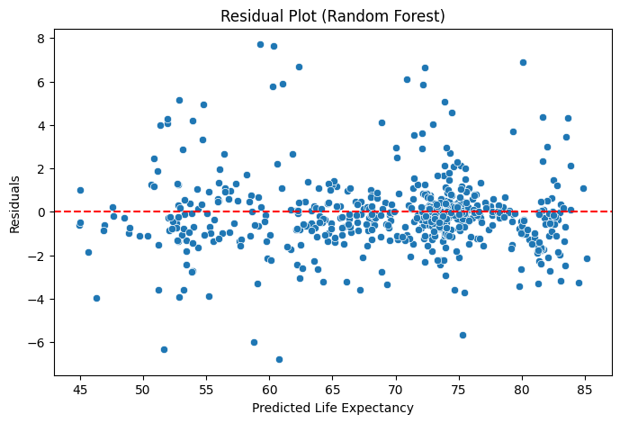

```python
# Residual plots of Random Forest model
residuals = y_test - y_pred_rf

plt.figure(figsize=(8, 5))
sns.scatterplot(x=y_pred_rf, y=residuals)
plt.axhline(0, color='red', linestyle='--')
plt.xlabel("Predicted Life Expectancy")
plt.ylabel("Residuals")
plt.title("Residual Plot (Random Forest)")
plt.show()
```

- X-axis: Predicted values of life expectancy
- Y-axis: Residuals (i.e., actual − predicted values)

Each dot shows how far off the model's prediction is.

**Interpretation**

- The Random Forest model is doing very well.
- It doesn’t systematically over- or under-predict at any specific range.
- No strong heteroscedasticity or bias: residuals are fairly evenly distributed.

We can be confident that:

- The model is not overfitting.
- There's no major issue in model assumptions.
- The model generalizes well, which was also confirmed by cross-validation.

### Saving the Model

```python
import joblib

# Save the model
joblib.dump(rf, 'random_forest_model.pkl')
```

```
['random_forest_model.pkl']
```